# What Drives Ground-Level Ozone in Beijing?

Sidrah Nawaz

2026-07-13

We are using the ‘Aotizhongxin’ station dataset for now, think about expanding to other datasets if time!!

```r
# Read the CSV
air <- read.csv("PRSA_Data_Aotizhongxin_20130301-20170228.csv", stringsAsFactors = FALSE)

# Quick peek into data, everything checks out
glimpse(air)
```

```
## Rows: 35,064
## Columns: 18
## $ No      <int> 1, 2, 3, 4, 5, 6, 7, 8, 9, 10, 11, 12, 13, 14, 15, 16, 17, 18,…
## $ year    <int> 2013, 2013, 2013, 2013, 2013, 2013, 2013, 2013, 2013, 2013, 20…
## $ month   <int> 3, 3, 3, 3, 3, 3, 3, 3, 3, 3, 3, 3, 3, 3, 3, 3, 3, 3, 3, 3, 3,…
## $ day     <int> 1, 1, 1, 1, 1, 1, 1, 1, 1, 1, 1, 1, 1, 1, 1, 1, 1, 1, 1, 1, 1,…
## $ hour    <int> 0, 1, 2, 3, 4, 5, 6, 7, 8, 9, 10, 11, 12, 13, 14, 15, 16, 17, …
## $ PM2.5   <dbl> 4, 8, 7, 6, 3, 5, 3, 3, 3, 3, 3, 3, 3, 3, 6, 8, 9, 10, 11, 8, …
## $ PM10    <dbl> 4, 8, 7, 6, 3, 5, 3, 6, 6, 8, 6, 6, 6, 6, 9, 15, 19, 23, 20, 1…
## $ SO2     <dbl> 4, 4, 5, 11, 12, 18, 18, 19, 16, 12, 9, 9, 7, 7, 7, 7, 9, 11, …
## $ NO2     <dbl> 7, 7, 10, 11, 12, 18, 32, 41, 43, 28, 12, 14, 13, 12, 11, 14, …
## $ CO      <int> 300, 300, 300, 300, 300, 400, 500, 500, 500, 400, 400, 400, 30…
## $ O3      <dbl> 77, 77, 73, 72, 72, 66, 50, 43, 45, 59, 72, 71, 74, 76, 77, 76…
## $ TEMP    <dbl> -0.7, -1.1, -1.1, -1.4, -2.0, -2.2, -2.6, -1.6, 0.1, 1.2, 1.9,…
## $ PRES    <dbl> 1023.0, 1023.2, 1023.5, 1024.5, 1025.2, 1025.6, 1026.5, 1027.4…
## $ DEWP    <dbl> -18.8, -18.2, -18.2, -19.4, -19.5, -19.6, -19.1, -19.1, -19.2,…
## $ RAIN    <dbl> 0, 0, 0, 0, 0, 0, 0, 0, 0, 0, 0, 0, 0, 0, 0, 0, 0, 0, 0, 0, 0,…
## $ wd      <chr> "NNW", "N", "NNW", "NW", "N", "N", "NNE", "NNW", "NNW", "N", "…
## $ WSPM    <dbl> 4.4, 4.7, 5.6, 3.1, 2.0, 3.7, 2.5, 3.8, 4.1, 2.6, 3.6, 3.7, 5.…
## $ station <chr> "Aotizhongxin", "Aotizhongxin", "Aotizhongxin", "Aotizhongxin"…
```

```r
dim(air)
```

```
## [1] 35064    18
```

O3 has 1,719 missing values. Since O3 is the target variable, let’s remove them rather than impute

```r
# Summary statistics
summary(air$O3)
```

```
##     Min.  1st Qu.   Median     Mean  3rd Qu.     Max.     NA's
##   0.2142   8.0000  42.0000  56.3534  82.0000 423.0000     1719
```

```r
# Check missing values
sum(is.na(air$O3))
```

```
## [1] 1719
```

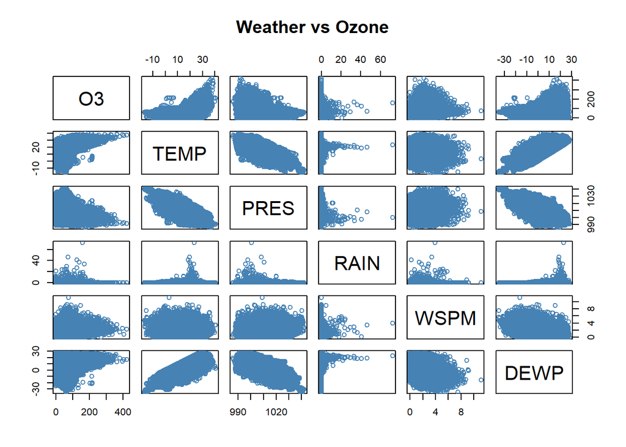

```r
# Select only the weather variables and O3
weather_data <- air %>%
  select(O3, TEMP, PRES, RAIN, WSPM, DEWP)  # These are the numerical weather factors, technically wd is a potential factor as well but I didn't include that!


# Pairwise scatterplots
pairs(weather_data, col = "steelblue", main = "Weather vs Ozone")
```

From the pairwise scatterplot shown above, I can visually see there is a positive correlation between O3 and TEMP, and O3 and DEWP. O3 and RAIN is kind of weird…, sort of like a negative correlation. O3 and PRES has a clear negative correlation. O3 and WSPM has somewhat of a negative correlation.

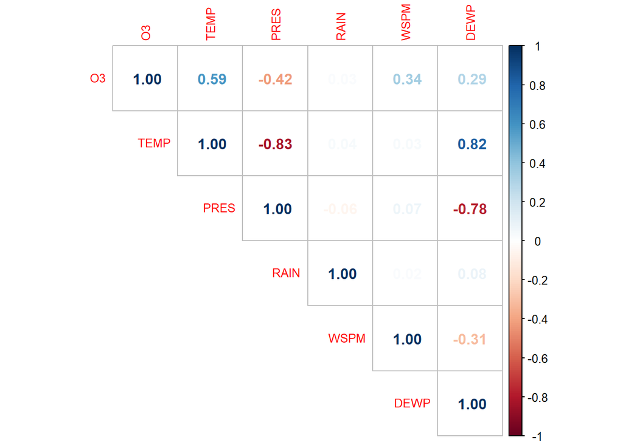

```r
cor_matrix <- cor(weather_data, use = "complete.obs")
corrplot(cor_matrix, method = "number", type = "upper", tl.cex = 0.8)
```

Okay odd… Now the actual correlations say O3 and TEMP, WSPM, and DEWP have a positive correlation, O3 and RAIN is almost like 0 lol which is pretty accurate, and O3 and PRES has a negative correlation.

Very interesting! I have apparently encountered the “Simpson’s paradox,” as I thought WSPM was negative, but it’s actually a positive correlation!

Since this is a time series, we need to split based of: Train on the PAST, test on the FUTURE. It’s kind of like cheating if we train on the future and test in the past since the factors would already have been determined for what impacts the Ozone

```r
# 1. Remove rows where O3 is missing
air_clean <- air %>% filter(!is.na(O3))

# 2. Impute missing weather variables with median
air_clean <- air_clean %>%
  mutate(
    TEMP = ifelse(is.na(TEMP), median(TEMP, na.rm = TRUE), TEMP),
    RAIN = ifelse(is.na(RAIN), median(RAIN, na.rm = TRUE), RAIN),
    WSPM = ifelse(is.na(WSPM), median(WSPM, na.rm = TRUE), WSPM),
    PRES = ifelse(is.na(PRES), median(PRES, na.rm = TRUE), PRES),
    DEWP = ifelse(is.na(DEWP), median(DEWP, na.rm = TRUE), DEWP)
  )

# 3. Select only the weather features
model_data <- air_clean %>%
  select(O3, TEMP, RAIN, WSPM, PRES, DEWP)

# 4. Train/Test Split by Year (like the Smarket split thingy)
train_idx <- air_clean$year < 2016
test_idx <- !train_idx

x_train <- model_data[train_idx, ] %>% select(-O3)
y_train <- model_data[train_idx, ]$O3
x_test <- model_data[test_idx, ] %>% select(-O3)
y_test <- model_data[test_idx, ]$O3

# Check sizes
dim(x_train)
```

```
## [1] 23447     5
```

```r
dim(x_test)
```

```
## [1] 9898    5
```

```r
lm_fit <- lm(O3 ~ ., data = model_data[train_idx, ])
summary(lm_fit)
```

```
##
## Call:
## lm(formula = O3 ~ ., data = model_data[train_idx, ])
##
## Residuals:
##      Min       1Q   Median       3Q      Max
## -135.598  -28.476   -3.462   20.642  276.945
##
## Coefficients:
##             Estimate Std. Error t value Pr(>|t|)
## (Intercept) 11.74604   49.28590   0.238    0.812
## TEMP         4.56467    0.05699  80.101  < 2e-16 ***
## RAIN         1.91493    0.30387   6.302 2.99e-10 ***
## WSPM         8.65166    0.28457  30.403  < 2e-16 ***
## PRES        -0.03058    0.04834  -0.633    0.527
## DEWP        -1.51253    0.04571 -33.090  < 2e-16 ***
## ---
## Signif. codes:  0 '***' 0.001 '**' 0.01 '*' 0.05 '.' 0.1 ' ' 1
##
## Residual standard error: 42.02 on 23441 degrees of freedom
## Multiple R-squared:  0.4755, Adjusted R-squared:  0.4754
## F-statistic:  4251 on 5 and 23441 DF,  p-value: < 2.2e-16
```

```r
library(leaps)
bestsubs_fit <- regsubsets(O3 ~ ., data = model_data[train_idx, ], nvmax = 5)
summary(bestsubs_fit)
```

```
## Subset selection object
## Call: regsubsets.formula(O3 ~ ., data = model_data[train_idx, ], nvmax = 5)
## 5 Variables  (and intercept)
##      Forced in Forced out
## TEMP     FALSE      FALSE
## RAIN     FALSE      FALSE
## WSPM     FALSE      FALSE
## PRES     FALSE      FALSE
## DEWP     FALSE      FALSE
## 1 subsets of each size up to 5
## Selection Algorithm: exhaustive
##          TEMP RAIN WSPM PRES DEWP
## 1  ( 1 ) "*"  " "  " "  " "  " "
## 2  ( 1 ) "*"  " "  " "  " "  "*"
## 3  ( 1 ) "*"  " "  "*"  " "  "*"
## 4  ( 1 ) "*"  "*"  "*"  " "  "*"
## 5  ( 1 ) "*"  "*"  "*"  "*"  "*"
```

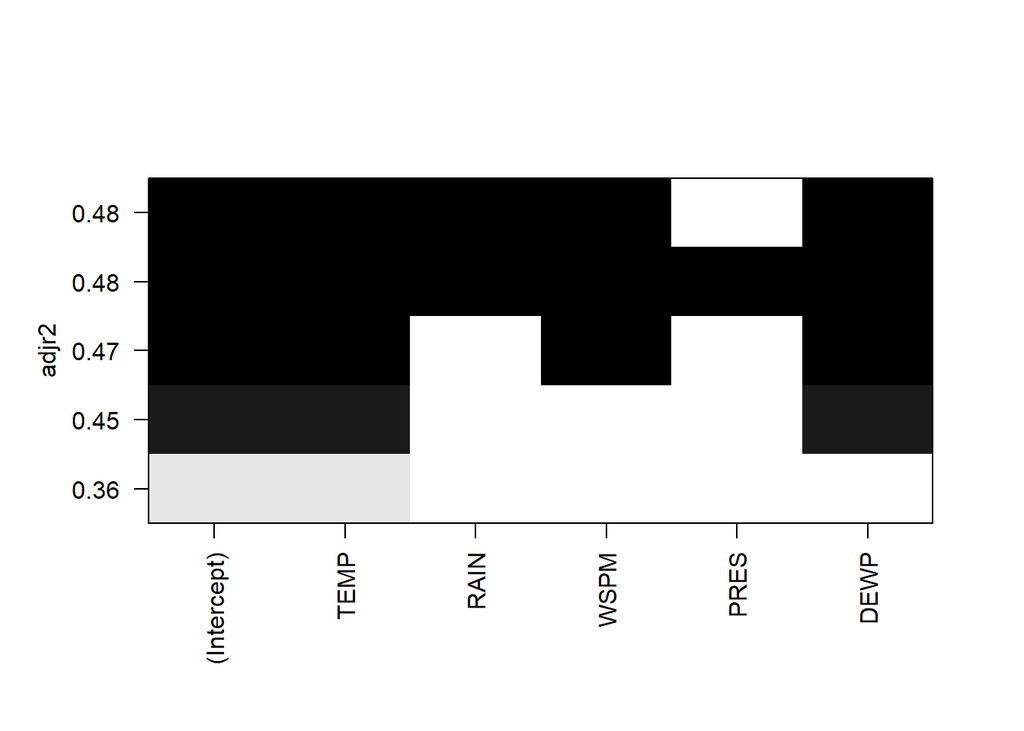

```r
# Plot the coefficients to see which variables enter the model
plot(bestsubs_fit, scale = "adjr2")
```

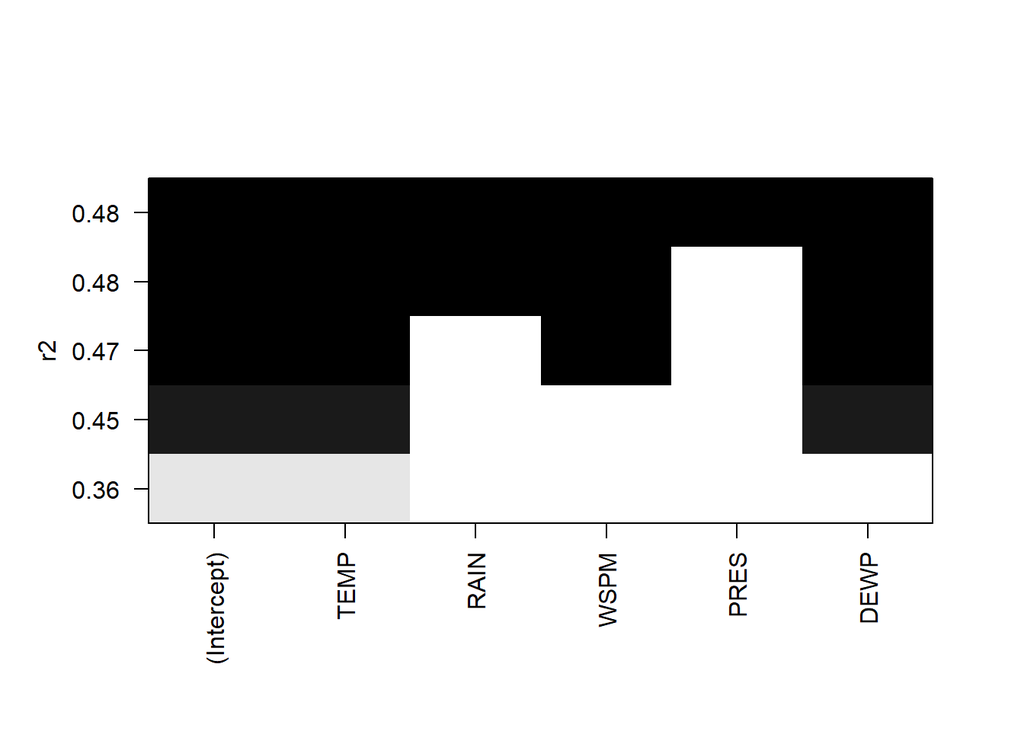

```r
plot(bestsubs_fit, scale = "r2")
```

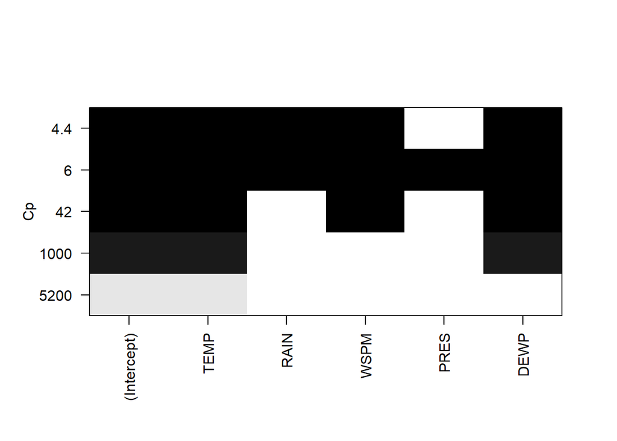

```r
plot(bestsubs_fit, scale = "Cp")
```

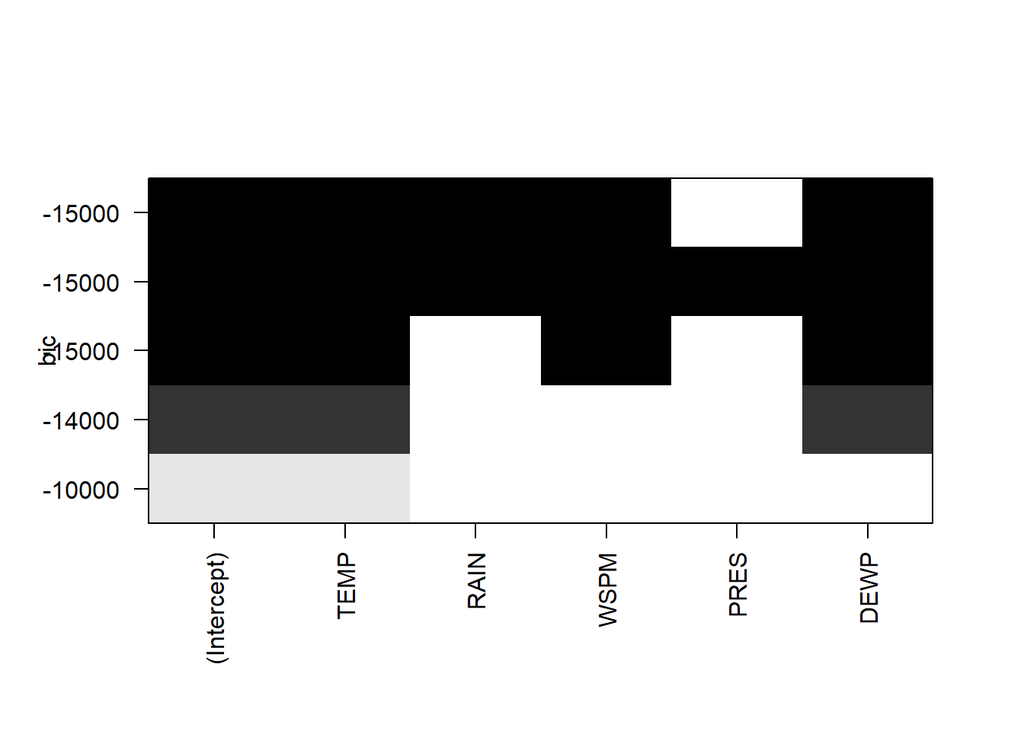

```r
plot(bestsubs_fit, scale = "bic")
```

We see here that TEMP, WSPM, and DEWP are the top 3 variables for literally all: adjr2, BIC, Cp, r2! This is for the Best Subset Selection method. Nice and accurate basically.

```r
# Prepare matrix
x_train_mat <- as.matrix(x_train)
x_test_mat <- as.matrix(x_test)

# Grid of lambda values
grid <- 10^seq(10, -2, length = 100)

# Ridge
ridge_cv <- cv.glmnet(x_train_mat, y_train, alpha = 0, lambda = grid)
best_ridge_lambda <- ridge_cv$lambda.min

# Extract coefficients at best lambda
ridge_coef <- coef(ridge_cv, s = best_ridge_lambda)
ridge_coef
```

```
## 6 x 1 sparse Matrix of class "dgCMatrix"
##                  s=0.01
## (Intercept) 12.49100506
## TEMP         4.55635355
## RAIN         1.90917784
## WSPM         8.67791312
## PRES        -0.03126775
## DEWP        -1.50624925
```

I don’t understand the Ridge Regression method AS MUCH as Lasso, but interestingly we’re getting very very similar numeric results for both methods! This means (I think) that the model is already really stable, so there doesn’t have to be extreme changes to the coefficients. But then that kind of means these methods are not as significant/necessary, and linear modeling is perfectly fine.

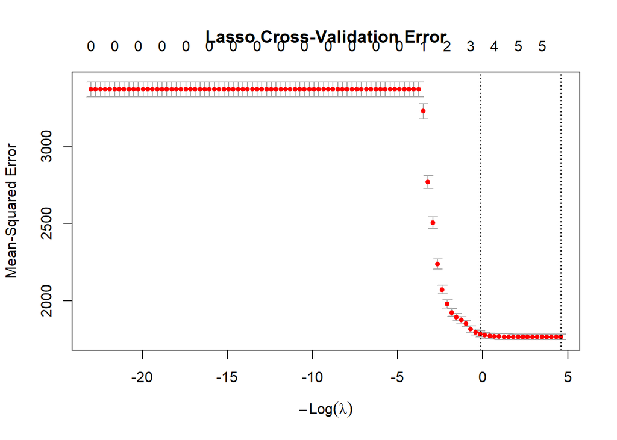

```r
# Fit Lasso with cross-validation
set.seed(1)
lasso_cv <- cv.glmnet(x_train_mat, y_train, alpha = 1, lambda = grid)

# Plot the cross-validation error
plot(lasso_cv, main = "Lasso Cross-Validation Error")
```

```r
# Find the best lambda
best_lasso_lambda <- lasso_cv$lambda.min
best_lasso_lambda
```

```
## [1] 0.01
```

```r
# Extract coefficients at the optimal penalty
lasso_coef <- coef(lasso_cv, s = best_lasso_lambda)
lasso_coef
```

```
## 6 x 1 sparse Matrix of class "dgCMatrix"
##                  s=0.01
## (Intercept)  9.53650045
## TEMP         4.55488785
## RAIN         1.89677262
## WSPM         8.68209722
## PRES        -0.02834432
## DEWP        -1.50289501
```

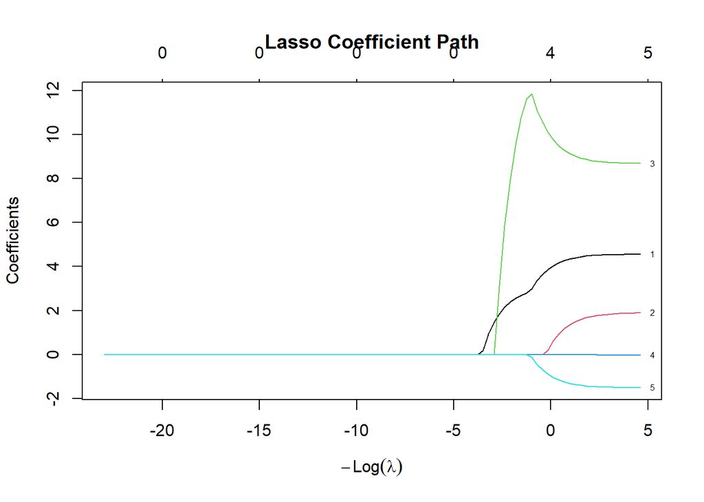

```r
lasso_full <- glmnet(x_train_mat, y_train, alpha = 1, lambda = grid)
plot(lasso_full, xvar = "lambda", label = TRUE, main = "Lasso Coefficient Path")
```

```r
# This plot shows variables dropping to zero as lambda increases.
```

```r
# Predict on test set using Lasso
lasso_pred <- predict(lasso_cv, newx = x_test_mat, s = best_lasso_lambda)
lasso_test_mse <- mean((lasso_pred - y_test)^2)

# Baseline (just using the mean)
null_mse <- mean((mean(y_train) - y_test)^2)

# Compile results
results_df <- data.frame(
  Model = c("Null (Mean)", "Lasso"),
  Test_MSE = c(null_mse, lasso_test_mse)
)
knitr::kable(results_df, caption = "Test Set Performance", digits = 2)
```

Test Set Performance

| Model | Test_MSE |
| --- | --- |
| Null (Mean) | 3335.12 |
| Lasso | 1704.62 |

```r
# Final Coefficient Table
coef_table <- data.frame(
  Variable = rownames(lasso_coef)[-1],
  Coefficient = as.vector(lasso_coef[-1])
)
knitr::kable(coef_table, caption = "Lasso Coefficients at Best Lambda", digits = 3)
```

Lasso Coefficients at Best Lambda

| Variable | Coefficient |
| --- | --- |
| TEMP | 4.555 |
| RAIN | 1.897 |
| WSPM | 8.682 |
| PRES | -0.028 |
| DEWP | -1.503 |

Lasso test MSE is 1704.62, and the Null model MSE is 3335.12….. basically, our weather-based model significantly outperforms the predicted average!

SOURCES

Chapters #2 - #9: R Lab Codes https://archive.ics.uci.edu/dataset/501/beijing+multi+site+air+quality+data https://www.r-bloggers.com/2013/01/scatterplot-matrices/ https://www.shawmeters.com/the-role-of-dewpoint-measurement-in-ozone-generation/ https://www.sciencedirect.com/science/article/abs/pii/S1383586622010851 https://news.harvard.edu/gazette/story/2016/04/the-complex-relationship-between-heat-and-ozone/ https://www.epa.gov/air-trends/trends-ozone-adjusted-weather-conditions https://www.researchgate.net/post/What-does-it-indicating-If-there-is-positive-correlation-but-negative-regression-coefficient https://discovery.cs.illinois.edu/learn/Basics-of-Data-Science-with-Python/Simpsons-Paradox/ https://pmc.ncbi.nlm.nih.gov/articles/PMC6107969/ https://www.datanovia.com/learn/machine-learning/model-selection/best-subsets-regression https://medium.com/@LauraHKahn/machine-learning-for-beginners-part-11-ridge-regression-9c606c764c2a https://ujangriswanto08.medium.com/a-beginners-guide-to-lasso-regression-when-and-how-to-use-it-dc872e4ee489 https://www.rdocumentation.org/packages/glmnet/versions/5.0/topics/cv.glmnet